# Data and model summaries in R

Mark Scheuerell

3 April 2026

# Background

This is meant to be a helpful resource for R functions commonly used when working with data, fitting models, and interpreting output.

# Data summaries

Here are some functions that are helpful for summarizing data contained in a vector `x`.

`mean(x)`: computes the arithmetic mean (average) of `x`

`sd(x)`: computes the standard deviation of `x`

`var(x)`: computes the variance of `x`

`quantile(x)`: returns estimates of underlying distribution quantiles of `x`

`hist(x)`: creates a histogram of `x`

# Random numbers

It’s common practice to use some form of randomization when estimating and testing models.

`sample()`: draws a sample of a specified size from a group, with or without replacement

```r
## make all of this reproducible
set.seed(514)

## a sequence from 1 to 10
xx <- seq(1, 10)

## shuffle the order
sample(xx, size = length(xx), replace = FALSE)
```

```
##  [1]  6  7  9  3 10  2  1  5  8  4
```

```r
## grab 3 numbers at random
sample(xx, size = 3, replace = FALSE)
```

```
## [1] 2 7 8
```

## Distributional forms

The functions for generating random data from a statistic distribution in R all start with `r` (for “random”).

### Continuous values

Continuous values can occur anywhere on the entire real number line from -∞ to ∞, but some have a necessary lower bound at zero (e.g., densities, concentrations).

#### Normal

`rnorm()`: draw random samples from a normal distribution

```r
## 1000 values from a normal distribution with mean = 25 and variance = 5
xx <- rnorm(n = 1000, mean = 25, sd = sqrt(5))

## estimated mean and variance
mean(xx); var(xx)
```

```
## [1] 25.03982
```

```
## [1] 4.835364
```

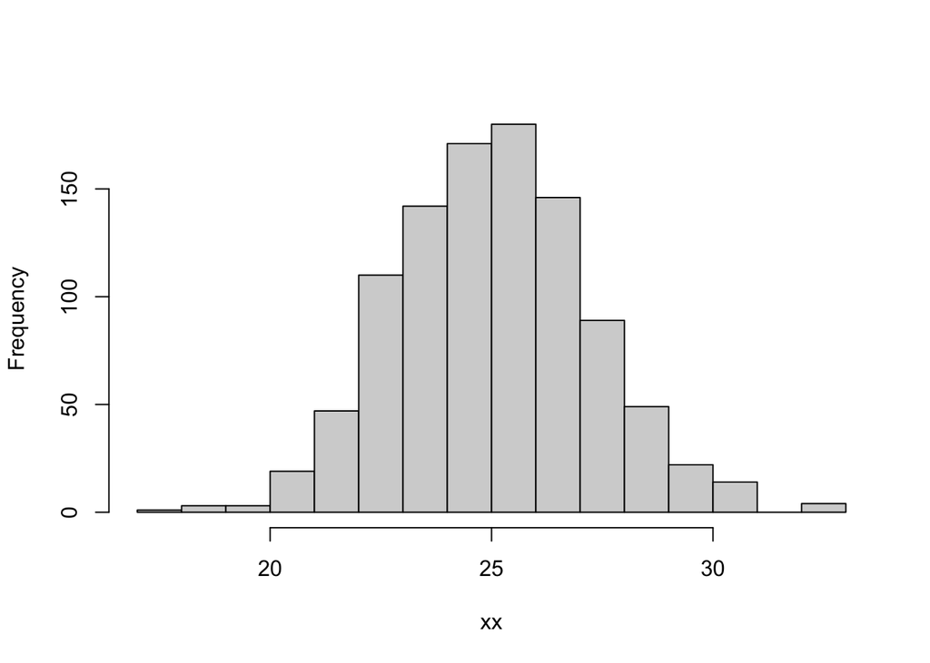

```r
## histogram of values
hist(xx, main = "",
     breaks = seq(floor(min(xx)), ceiling(max(xx))))
```

#### Logistic

`rlogis()`: draw random samples from a logistic distribution

#### Uniform

`runif()`: draw random samples from a uniform distribution

### Discrete values

Discrete values are integers that typically only take on non-negative values (e.g., presence/absence, counts).

#### Bernoulli & Binomial

`rbinom()`: draw random samples from a binomial distribution; can be used for Bernoulli distribution as well

Simulated “coin toss” via Bernoulli

```r
## flip a coin 1000 times
xx <- rbinom(n = 1000, size = 1, prob = 0.5)

## count tails (0) and heads (1)
table(xx)
```

```
## xx
##   0   1
## 499 501
```

Simulated survival

```r
## 1357 tagged smolts; probability of survival is 0.05
xx <- rbinom(n = 1357, size = 1, prob = 0.05)

## number of mortalities (0) and survivors (1)
table(xx)  # p ~= 0.0528
```

```
## xx
##    0    1
## 1289   68
```

#### Poisson

`rpois()`: draw random samples from a Poisson distribution

```r
## 1000 values from a Poisson distribution with mean = variance = 25
xx <- rpois(n = 1000, lambda = 25)

## estimated mean and variance
mean(xx); var(xx)
```

```
## [1] 24.935
```

```
## [1] 25.56234
```

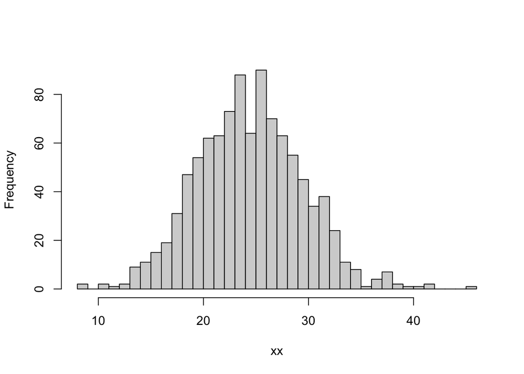

```r
## histogram of values
hist(xx, main = "",
     breaks = seq(floor(min(xx)), ceiling(max(xx))))
```

#### Negative binomial

`rnbinom()`: draw random samples from a negative binomial distribution

```r
## 1000 values from a negative binomial distribution with mean = 25 and variance = 50
xx <- rnbinom(n = 1000, mu = 25, size = 25)

## estimated mean and variance
mean(xx); var(xx)
```

```
## [1] 25.487
```

```
## [1] 52.02786
```

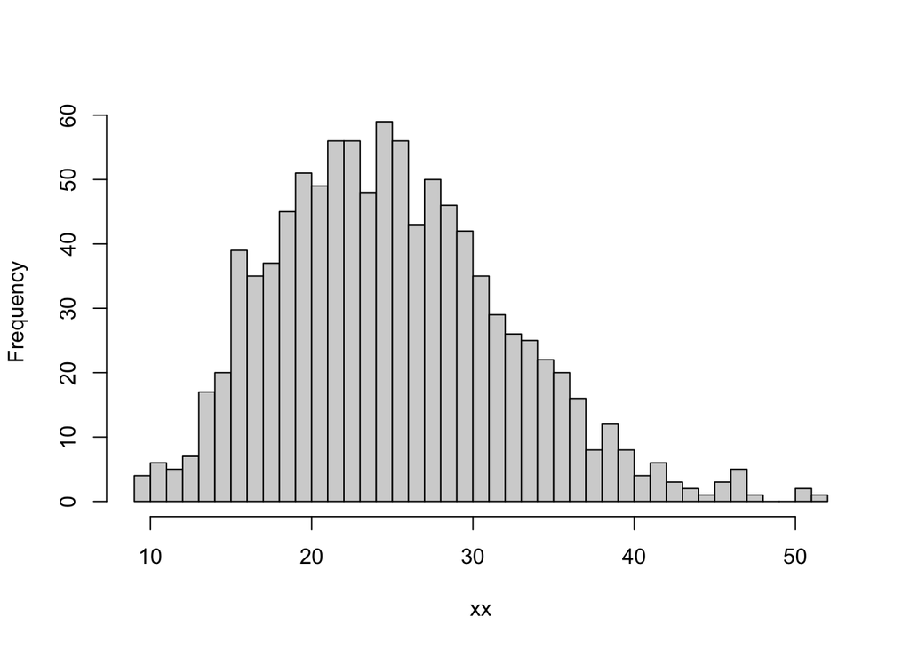

```r
## histogram of values
hist(xx, main = "",
     breaks = seq(floor(min(xx)), ceiling(max(xx))))
```

# Data in models

Sometimes you want or need to be very explicit about how you want R to treat some aspect of your data. For example, when used inside of a model-fitting function, `a + b` will include both `a` and `b` as predictors in a model, but `I(a + b)` will include the sum of `a` and `b` as a single predictor in a model.

`I()`: change the class of an object to indicate that it should be treated ‘as is’

```r
lm(y ~ I(x + z))
```

`offset()`: assume a model predictor has a known coefficient of 1 rather than an unknown coefficient to be estimated

For example, if we counted 6 plants inside a 2 m<sup>2</sup> quadrat, we might express the density of plants as 3 plants per m<sup>2</sup>. As you will see later, models for counts often assume a log-linear relationship, such that

$$\log (\text{density}) = \alpha + \beta x \\
\Downarrow \\
\log(\text{number} ~/~ \text{m}^2) = \alpha + \beta x \\
\log(\text{number}) - \log(\text{m}^2) = \alpha + \beta x \\
\log(\text{number}) = \alpha + \beta x + \log(\text{m}^2)\\$$

We might model this relationship in R with something like

```r
## log-linear regression
lm(log(number) ~ x + offset(log(area)))
```

`scale()`: shifts and/or scales a vector to have a mean of 0 and variance or 1

```r
## random variate with mean of 5 and variance of 2
xx <- rnorm(100, mean = 5, sd = sqrt(2))

## scaled values with mean = 0 and variance = 1
zz <- scale(xx)
mean(zz); var(zz)
```

```
## [1] -2.60829e-16
```

```
##      [,1]
## [1,]    1
```

# Model summaries

You’ll see a variety of functions for fitting different types of linear models in this course. The following functions are useful for extracting information about a fitted model, such as estimated coefficients, standard errors, and p-values.

`anova()`: computes analysis of variance (or deviance) table for a fitted model object

`coefficients()`: extracts model coefficients from objects returned by modeling functions

`residuals()`: extracts model residuals from objects returned by modeling functions

`summary()`: returns a list of summary statistics of the fitted linear model

# Monte Carlo

There is a technique known as a *Monte Carlo* method (or simulation or experiment), whose name comes from the Monte Carlo Casino in Monaco. The idea is to estimate the uncertainty in a stochastic variable or process via repeated sampling. For example, say you wanted to estimate the probability that a coin would come up “heads” when flipped into the air and allowed to land freely. To do so, you could flip the coin 1000 times and after each flip record a 1 if heads or a 0 if tails. At the end count up the number of 1’s and divide the sum by 1000. Here’s a way we might do that in R.

```r
## number of monte carlo experiments
nn <- 1000

## empty vector to record our results
rr <- rep(NA, nn)

## make this repeatable
set.seed(514)

## conduct the experiment
for(i in 1:nn) {
  ## flip the coin; rbinom(1, 1, 0.5) will return a 0 or 1 with probability 0.5
  flip <- rbinom(1, 1, 0.5)
  ## record the result
  rr[i] <- flip
}

## estimate probability of heads
sum(rr) / nn
```

```
## [1] 0.489
```